# TMA4315 Generalized linear models H2018

Module 3: BINARY REGRESSION

Mette Langaas, Department of Mathematical Sciences, NTNU - with contributions from Øyvind Bakke, Thea Bjørnland and Ingeborg Hem

13.09 and 20.09 [PL], 14.09 and 21.09 [IL]

# Interactive lecture - first week

## Theoretical questions - with and without use of R

### Problem 1: Model assumptions

1. What are the model assumptions for a binary regression?

**Solution**

1. Random component: Distribution of response:$Y_i \sim \text{bin}(n_i,\pi_i)$. $n_i$ is a known constant, $p_i$ is what we are modelling.
2. Systematic component: Linear predictor: $\eta_i={\bf x}_i^T \boldsymbol{\beta}$. Here ${\bf x}_i$ is our fixed (not random) $p$-dimensional column vector of covariates (intercept included).
3. Link: Connection between the linear predictor and the mean (parameter of interest): $g(\mu_i)=\eta_i$. For the moment we have not specified $g()$.
4. We assume each $\{ \pi_i, \bf{x}_i^T\}$ is independent of the the others.
2. Which link function and response function is used for the logit model?

**Solution**

Link function: $\eta_i = \log{\frac{\mu_i}{1-\mu_i}}$

Response function: $\mu_i = p_i = \frac{e^{eta_i}}{1+e^{eta_i}}$

3. What is the difference between the logit model and a logistic regression?

**Solution**

Ask a historian of statistics! They are the same thing, but probably have a complicated history with different people giving them different names.

### Problem 2: Log-likelihood.

1. What is the definition of the log-likelihood?

**Solution**

The likelihood for a single point is (in general) $L(\theta| y_i) = P(y_i| \theta)$, and for the whole data is (assuming independence) $L(\theta| {\bf{y}}) = \prod_i P(y_i| \theta)$.

So the log likelihood is $l(\theta| {\bf{y}}) = \log L(\theta| {\bf{y}}) = \log \prod_i P(y_i| \theta) = \sum_i l(\theta| y_i)$.

2. For the logit model the log-likelihood is
   $$l(\boldsymbol{\beta})=\sum_{j=1}^G[\ln
   \binom{n_j}{y_j}+ y_j \ln
   \pi_j-y_j\ln(1-\pi_j)+n_j\ln(1-\pi_j)]$$
   for grouped data.

Explain how we have arrived at this formula.

**Solution**

For a single datum the likelihood is

$L(\boldsymbol{\beta})=P(y_j|\boldsymbol{\beta}) = \binom{n_j}{y_j} \pi_j^{y_j} (1-\pi_j^{n_j-y_j})$

So we take logs and sum over the data (see the answer to Q2a) to get

$$\begin{aligned}
l(\boldsymbol{\beta})&=\sum_{j=1}^G[\ln \binom{n_j}{y_j}+ y_j \ln
\pi_j-+(n_j-y_j)\ln(1-\pi_j)] \\
&=\sum_{j=1}^G[\ln \binom{n_j}{y_j}+ y_j \ln
\pi_j-y_j\ln(1-\pi_j)+n_j\ln(1-\pi_j)] \\
\end{aligned}$$

3. Write the version of the loglikelihood for individual data (i.e. $n_j=1$ and $G=n$).

**Solution**

$$l(\boldsymbol{\beta})=\sum_{j=1}^G[y_j
\ln \pi_j-y_j\ln(1-\pi_j)+\ln(1-\pi_j)]$$

4. Where is $\boldsymbol{\beta}$ in the loglikelihood in c? Rewrite this to be a function of $\boldsymbol{\beta}$.

**Solution**

$\boldsymbol{\beta}$ is in the systematic part, which is used to calculate $\pi_i$: $p_i = \frac{e^{eta_i}}{1+e^{eta_i}} = \frac{e^{{\bf{x}}_i^T \boldsymbol{\beta}}}{1+e^{{\bf{x}}_i^T \boldsymbol{\beta}}}$. Or, ${\bf{x}}_i^T \boldsymbol{\beta} = \log{\frac{\mu_i}{1-\mu_i}}$

So we can rewrite the likelihood as

$$\begin{aligned}
l(\boldsymbol{\beta})&=\sum_{j=1}^G[y_j (\ln
\pi_j-\ln(1-\pi_j))+\ln(1-\pi_j)] \\
&=\sum_{j=1}^G[y_j (\ln \frac{\pi_j}{1-\pi_j})+\ln(1-\pi_j)] \\
&=\sum_{j=1}^G[y_j {\bf{x}}_i^T \boldsymbol{\beta}+\ln(1-\pi_j)] \\
\end{aligned}$$

And then because

$$\ln(1-\pi_j) = \ln(1-\frac{e^{{\bf{x}}_i^T
\boldsymbol{\beta}}}{1+e^{{\bf{x}}_i^T \boldsymbol{\beta}}}) =
\ln(\frac{1}{1+e^{{\bf{x}}_i^T \boldsymbol{\beta}}}) =
-\ln(1+e^{{\bf{x}}_i^T \boldsymbol{\beta}})$$

we end up with

$$l(\boldsymbol{\beta})=\sum_{j=1}^G[y_j {\bf{x}}_i^T
\boldsymbol{\beta}-\ln(1+e^{{\bf{x}}_i^T \boldsymbol{\beta}})] \\$$

5. Why can we ignore the normalizing constant (what is the constant?) in the case of $n_j = 1 \ \forall j$? Considering what the log-likelihood is used for, why can we ignore the normalizing constant in all cases (i.e., also when $n_j \neq 1$)?

**Solution**

For $n_j = 1$ the normalising constant is $\frac{1!}{1!0!} = 1$

When $n_j \gt 1$, the normalising constant is not 1. But we only use the likelihood in differences between log likelihoods or when differentiating to get the score. In both these case the constant disappears.

The beetle data has only one covariate (in addition to the intercept) - so this means that we have $\boldsymbol{\beta}=(\boldsymbol{\beta}_0,\boldsymbol{\beta}_1)$. Look at the following code and work out what is done - remark: we have used the $n_i=1$ version of the loglikelihood here.

```r
library(investr)
library(ggplot2)
library(viridis)

# from aggregated to individual data (because these data were aggregated)
ldose <- rep(investr::beetle$ldose, investr::beetle$n)
y <- NULL
for (i in 1:8) y = c(y, rep(0, investr::beetle$n[i] - investr::beetle$y[i]), rep(1,
    investr::beetle$y[i]))
beetleds = data.frame(killed = y, ldose = ldose)

loglik <- function(par, args) {
    y <- args$y
    x <- args$x
    n <- args$n
    res <- sum(y * x %*% par - n * log(1 + exp(x %*% par)))
    return(res)
}

loglik(c(1, 1), args = list(y = beetleds$killed, x = cbind(rep(1, nrow(beetleds)),
    beetleds$ldose), n = rep(1, nrow(beetleds))))
```

```
## [1] -549.2543
```

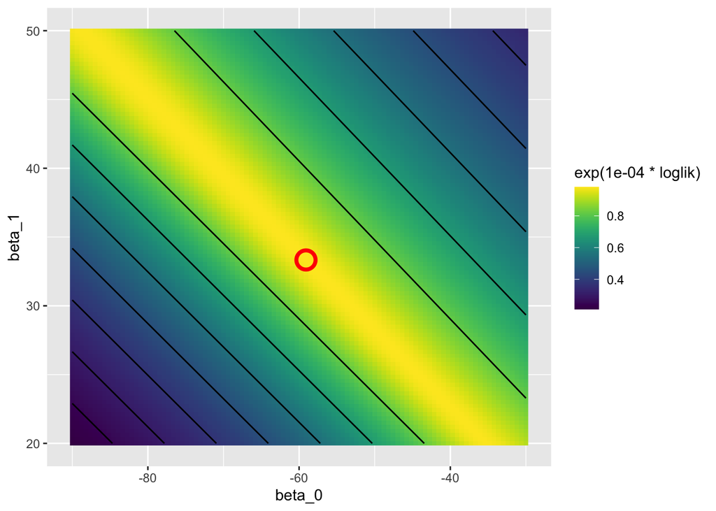

```r
loglikmat <- matrix(NA, nrow = 100, ncol = 100)
loglikframe <- data.frame()

# expand.grid() is a useful function in R (and will not be on the exam!).  If
# you can't work out what it's doing, try expand.grid(x=seq(1,2,length.out=3),
# y=seq(1,5, by=2)) and if you still can't, try reading the function from the
# inside: start with seq(1,2,length.out=3), see what it's doing and then look
# at the rest.
loglikframe <- expand.grid(beta_0 = seq(-90, -30, length.out = 100), beta_1 = seq(20,
    50, length.out = 100))

# apply() is a way of looping over rows/columns of a data frame or matrix, and
# applying a function to eacj row/column
loglikframe$loglik <- apply(loglikframe, 1, function(vec, args) {
    ll <- loglik(vec[c("beta_0", "beta_1")], args = args)
    ll
}, args = list(y = beetleds$killed, x = cbind(rep(1, nrow(beetleds)), beetleds$ldose),
    n = rep(1, nrow(beetleds))))


ggplot(data = loglikframe, mapping = aes(x = beta_0, y = beta_1, z = loglik)) + geom_raster(aes(fill = exp(1e-04 *
    loglik))) + geom_point(data = loglikframe[which.max(loglikframe$loglik), ], mapping = aes(x = beta_0,
    y = beta_1), size = 5, col = "red", shape = 21, stroke = 2) + scale_shape(solid = FALSE) +
    scale_fill_viridis() + geom_contour(col = "black")
```

6. What does this graph of $l$ look like as a function of $\boldsymbol{\beta}$ for the beetle data? First discuss shortly and then to aid you in answering this we look at the loglikelihood for the beetle data. Read the R code, discuss what is done and work on interpreting the final graph - in particular comment on the yellow ridge in the plot.

**Solution**

The graph looks approximately quadratic (in fact it is concave. We will see more in module 5). The yellow ridge is where the likelihood is largest for any value of $\beta_0$ or $\beta_1$. We can see this by looking at each value of $\beta_0$ and plotting the maximum:

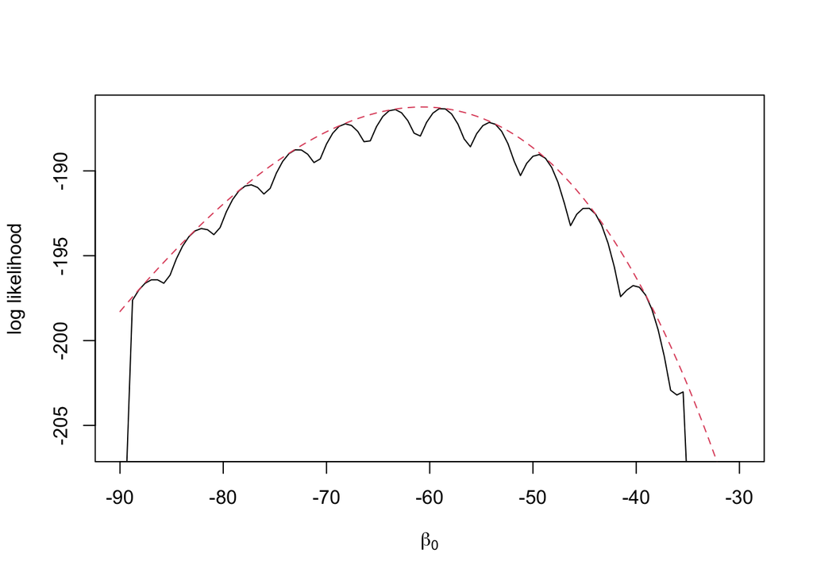

```r
Ridge <- tapply(loglikframe$loglik, list(loglikframe$beta_0), max)

Args = list(y = beetleds$killed, x = cbind(rep(1, nrow(beetleds)), beetleds$ldose),
    n = rep(1, nrow(beetleds)))

# loglikb0 <- function(b0, b1, args) loglik(c(b0,b1), args = args) # we don't
# use this, but we could
loglikb1 <- function(b1, b0, args) loglik(c(b0, b1), args = args)

beta0s <- unique(loglikframe$beta_0)
Ridgeb0 <- sapply(beta0s, function(b0, df, args) {
    opt <- optimize(loglikb1, interval = c(-200, 200), b0 = b0, args = args, maximum = TRUE)
    opt$objective

}, args = Args)

plot(as.numeric(names(Ridge)), Ridge, type = "l", ylim = c(max(Ridge) - 20, max(Ridge)),
    xlab = expression(beta[0]), ylab = "log likelihood")
lines(beta0s, Ridgeb0, col = 2, lty = 2)
```

The bumps are because we are looking at discrete values of $\beta_0$ and $\beta_1$, so for any value of $\beta_0$ the maximum of $\beta_1$ will be between the values we have calculated it at. If we mentally smooth over these we see that the curve is smooth. We can get the actual curve by maximising the likelihood for each value of $\beta_0$. This gives us the red line, which is called the *profile likelihood*.

Comments to the code: for the `loglik` function we have two arguments: par= the parameters to be estimated, and args=a list with data. The reason for only having these two arguments is that it is easier to use when we later perform optimization (with `optim`) of the loglikelihood to find the ML estimates.

### Problem 3: Score function

1. What is the definition of the score function? What is the dimension of the score function?

**Solution**

The score is the derivative of the log likelihood with respect to $\boldsymbol{\beta}$, the parameters:

$$s(\boldsymbol{\beta}) = \frac{\partial l(\boldsymbol{\beta}|y)}{\partial
\boldsymbol{\beta}}$$

With $k$ parameters the score is a vector of length $k$.

2. Derive the score function for the logit model (individual data).

The result should be

$$s(\boldsymbol{\beta})=\sum_{i=1}^n {\bf
x}_i (y_i-\pi_i)=\sum_{i=1}^n {\bf x}_i (y_i-\frac{\exp({\bf
x}_i^T\boldsymbol{\beta})}{1+\exp({\bf
x}_i^T\boldsymbol{\beta})})$$

**Solution**

First note that $s(\boldsymbol{\beta}) = \sum_i s_i(\boldsymbol{\beta})$, so we can work with $s_i(\boldsymbol{\beta})$:

$$s_i(\boldsymbol{\beta}) = \frac{\partial
l(\boldsymbol{\beta}|y_i)}{\partial \boldsymbol{\beta}}$$

Now use the chain rule to calculate $s_i(\boldsymbol{\beta})$.

$$s_i(\boldsymbol{\beta})
=
\frac{\partial l_i(\boldsymbol{\beta})}{\partial \boldsymbol{\beta}}
=
\frac{\partial l_i(\boldsymbol{\beta})}{\partial \eta_i}\cdot
\frac{\partial \eta_i}{\partial \boldsymbol{\beta}}$$

The second part first, because $\eta_i={\bf x}_i^T\boldsymbol{\beta}$, so we have

$$\frac{\partial [{\bf x}_i^T\boldsymbol{\beta} ]}{\partial
\boldsymbol{\beta}} = {\bf x}_i$$

Now the more difficult (=non-trivial) bit

$$\frac{\partial l_i(\boldsymbol{\beta})}{\partial \eta_i}
=
\frac{\partial [y_i\eta_i-\ln(1+{\exp(\eta_i)})]}{\partial \eta_i}$$

and we use the chain rule on $\frac{\partial \ln(1+{\exp(\eta_i)})}{\partial \eta_i}$, with $c=1+{\exp(\eta_i)}$ to get

$$\frac{\partial \ln(1+{\exp(\eta_i)})}{\partial \eta_i}
=
\frac{\partial \ln(c)}{\partial c}\frac{\partial c}{\partial \eta_i}
=
\frac{1}{1+{\exp(\eta_i)}}\exp(\eta_i) =
\frac{\exp(\eta_i)}{1+\exp(\eta_i)}$$

and thus

$$\frac{\partial [y_i\eta_i-\ln(1+{\exp(\eta_i)})]}{\partial \eta_i}
=
(y_i-\frac{\exp(\eta_i)}{1+\exp(\eta_i)})$$
Where $\frac{\exp(\eta_i)}{1+\exp(\eta_i)}=\pi_i$ (the probability of success, i.e. $E(y_i)$)

So the score for datum $i$ is

$$s_i(\boldsymbol{\beta}) = (y_i-\pi_i)$$

and the total score is (as predicted)

$$s(\boldsymbol{\beta})=\sum_{i=1}^n {\bf x}_i (y_i-\pi_i)=\sum_{i=1}^n
{\bf x}_i (y_i-\frac{\exp({\bf x}_i^T\boldsymbol{\beta})}{1+\exp({\bf
x}_i^T\boldsymbol{\beta})})$$

3. What do we need the score function for?

**Solution**

We mainly need it to find the maximum likelihood estimates, by solving $s(\boldsymbol{\beta})=0$. But we cal also use it in a score test

### Problem 4: Fisher information.

(We did not cover this in the lecture week 1, but we know one of the definitions from Module 2. Either you skip Problem 4 and move to Problem 5, or you look at the section “Properties of the score function”, and “The expected Fisher information matrix $F(\boldsymbol{\beta})$” together.)

1. What is the definition of the expected (and the observed) Fisher information matrix? What is the dimension of this matrix?

**Solution**

2. What is the role of these matrices in ML estimation?

**Solution**

3. For the logit model with grouped data the expected and the observed Fisher information matrix are equal and given as

$$F(\boldsymbol{\beta})=\sum_{j=1}^G {\bf
x}_j {\bf x}_j^T n_j \pi_j (1-\pi_j)$$
Where is $\boldsymbol{\beta}$ in this expression?

**Solution**

4. Write the version of the expected Fisher information for individual data (i.e. $n_j=1$ and $G=n$).

**Solution**

### Problem 5: Maximum likelihood

To find the ML estimate for $\boldsymbol{\beta}$ we may either use the function `glm` or optimize the log-likelihood manually. We will do both.

1. First we use the `glm` function in R, and we also check that the individual and the grouped data give the same parameter estimates for the $\boldsymbol{\beta}$.

Read the R-code, notice the different input structures and check the results.

**Solution**

```r
# the beetle.ds was made above
fitind = glm(killed ~ ldose, family = "binomial", data = beetleds)  # individual data
summary(fitind)
```

```
##
## Call:
## glm(formula = killed ~ ldose, family = "binomial", data = beetleds)
##
## Coefficients:
##             Estimate Std. Error z value Pr(>|z|)
## (Intercept)  -60.717      5.181  -11.72   <2e-16 ***
## ldose         34.270      2.912   11.77   <2e-16 ***
## ---
## Signif. codes:  0 '***' 0.001 '**' 0.01 '*' 0.05 '.' 0.1 ' ' 1
##
## (Dispersion parameter for binomial family taken to be 1)
##
##     Null deviance: 645.44  on 480  degrees of freedom
## Residual deviance: 372.47  on 479  degrees of freedom
## AIC: 376.47
##
## Number of Fisher Scoring iterations: 5
```

```r
fitgrouped = glm(cbind(y, n - y) ~ ldose, family = "binomial", data = investr::beetle)  # grouped data. response is #success AND #fails (here we have defined a dead beetle as a success)
summary(fitgrouped)
```

```
##
## Call:
## glm(formula = cbind(y, n - y) ~ ldose, family = "binomial", data = investr::beetle)
##
## Coefficients:
##             Estimate Std. Error z value Pr(>|z|)
## (Intercept)  -60.717      5.181  -11.72   <2e-16 ***
## ldose         34.270      2.912   11.77   <2e-16 ***
## ---
## Signif. codes:  0 '***' 0.001 '**' 0.01 '*' 0.05 '.' 0.1 ' ' 1
##
## (Dispersion parameter for binomial family taken to be 1)
##
##     Null deviance: 284.202  on 7  degrees of freedom
## Residual deviance:  11.232  on 6  degrees of freedom
## AIC: 41.43
##
## Number of Fisher Scoring iterations: 4
```

2. What is the default convergence criterion for the glm? (Note: IRWLS used in `glm` - more in Module 5.)

**Solution**

3. We implemented the log-likelihood as a function in item 2 above. Now we will use this together with the `optim` function on the beetle data set to optimize the loglikelihood. Read the R-code, take notice of how we put data into the `args` slot and how the optimization is called with `optim`. (In Compulsory exercise 2 you will use this in a Poisson regression.)

```r
loglik_gr <- function(par, args) {

    y <- args$y
    x <- args$x
    n <- args$n

    res <- y %*% x - t(t(n * x) %*% ((1 + exp(-x %*% par))^(-1)))
    return(res)
}

opt <- optim(c(-60, 30), fn = loglik, gr = loglik_gr, args = list(y = beetleds$killed,
    x = cbind(rep(1, nrow(beetleds)), beetleds$ldose), n = rep(1, nrow(beetleds))),
    control = list(fnscale = -1), hessian = TRUE, method = "BFGS")
opt
```

```
## $par
## [1] -60.71748  34.27034
##
## $value
## [1] -186.2354
##
## $counts
## function gradient
##       24        9
##
## $convergence
## [1] 0
##
## $message
## NULL
##
## $hessian
##            [,1]      [,2]
## [1,]  -58.48417 -104.0105
## [2,] -104.01047 -185.0941
```

```r
sqrt(diag(-solve(opt$hessian)))  # calculate the standard deviations of the parameters
```

```
## [1] 5.180709 2.912138
```

### Problem 6: Interpreting results

1. Interpret the estimated $\boldsymbol{\beta}$´s. Odds ratio is useful for this.

**Solution**

2. Plot the predicted probability of a beetle dying against the dosage and discuss what you see. (Yes, since this is the last question you may try to program by yourself!)

**Solution**

# References for further reading

- A. Agresti (2015): “Foundations of Linear and Generalized Linear Models.” Wiley.
- A. J. Dobson and A. G. Barnett (2008): “An Introduction to Generalized Linear Models”, Third edition.
- J. Faraway (2015): “Extending the Linear Model with R”, Second Edition. http://www.maths.bath.ac.uk/~jjf23/ELM/
- P. McCullagh and J. A. Nelder (1989): “Generalized Linear Models”. Second edition.